# Shifted TSS patterns in mTECs vs. Tissues analysis

Léonie Strömich

August 15, 2017

This script is used based on the list of matrices for each protein coding gene calculated in shifted_tss_patterns_mTECs_tissues.Rmd. The list was saved as .rds named list_genes_matrices_protein_coding.rds.

## Prerequisites

#### Load libraries

```r
library(reshape)
library(LSD)
library(ggplot2)
library(scales)
library(TxDb.Hsapiens.UCSC.hg19.knownGene)
library(biomaRt)
```

#### Read in Data

```r
### BioMart object
ensembl <- useMart(biomart="ENSEMBL_MART_ENSEMBL",
                   host="grch37.ensembl.org",
                   dataset="hsapiens_gene_ensembl")

###read in tra genes
tra_entrez <- read.table(file ="/home/stroemic/hiwi_16/analysis/gene_lists/human_tra_genes_sansom.csv", sep=",", header = TRUE)
##table with aire dep genes
aire_dep_genes <- read.table("/home/stroemic/hiwi_16/analysis/gene_lists/human_aire_dep_san_genes.csv", header=TRUE, sep=",")
##table with fezf2 dep genes
fezf2_dep_genes <- read.table("/home/stroemic/hiwi_16/analysis/gene_lists/human_fezf2_dep_genes.csv", header=TRUE, sep=",")

## merge aire and fezf2 dep genes with tra genes
aire_dep_tras <- merge(tra_entrez, aire_dep_genes, by="entrezgene")
fezf2_dep_tras <- merge(tra_entrez, fezf2_dep_genes, by="entrezgene")

#### read in List of gene matrices
list_genes <- readRDS(file="/home/stroemic/hiwi_16/analysis/shifted_TSS/list_genes_matrices_protein_coding.rds")
```

## Analysis

```r
##calculate p values
list_fisher <- lapply(list_genes, function(x) fisher.test(round(x[,1:2])))
```

#### Plot 1

Boxplot of ratios between counts in 5’UTR and CDS for tissues and mTECs

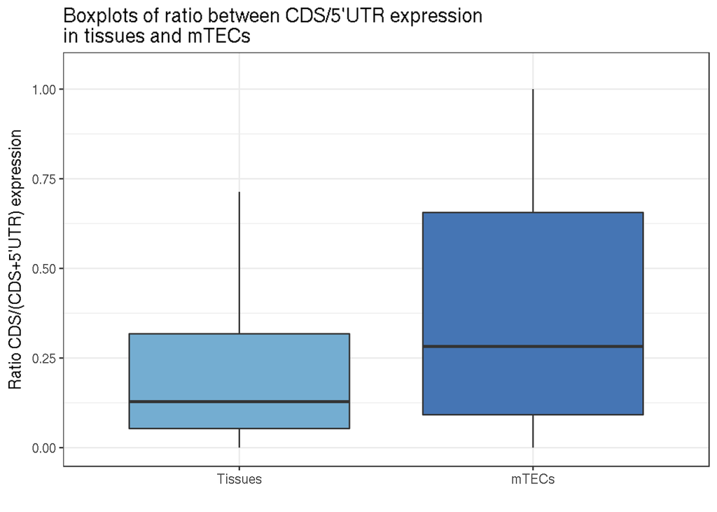

```r
##calculate ratios
ratio_tissues<- sapply(list_genes, function(x) x[1,2] / (x[1,1] + x[1,2]))
ratio_mTEC  <- sapply(list_genes, function(x) x[2,2] / (x[2,1] + x[2,2]))
##plot distribution in box_plots
df_ratios <- data.frame("Tissues"=ratio_tissues, "mTECs"=ratio_mTEC)
m_df_ratios <- melt(df_ratios)
#pdf(file="/home/stroemic/hiwi_16/analysis/shifted_TSS/plots/boxplot_ratios_tissues_mTECs.pdf")
p1 <- ggplot(m_df_ratios, aes(x=variable, y=value, fill=variable))
#set ylim dependent on hight of boxes taking the stats functions first and fifth entry ()
ylim1 = boxplot.stats(m_df_ratios$value)$stats[c(1, 5)]
p1 + geom_boxplot(outlier.size=NA) +  coord_cartesian(ylim = ylim1*1.05) +
    theme_bw() +
    labs(title="Boxplots of ratio between CDS/5'UTR expression \nin tissues and mTECs", x ="", y ="Ratio CDS/(CDS+5'UTR) expression") +
    scale_fill_manual(values = c('#74add1','#4575b4')) +
    guides(fill=FALSE)
```

```r
#dev.off()
```

#### Table of all genes

A table of all genes was created with the following characteristics for each gene:

- ratio of (CDS/CDS + 5’UTR) counts between mTECs and tissues
- p-value of independence of count distribution in 5’UTR and CDS between mTECs and tissues
- counts in 5’UTR and CDS for tissues and mTECs
- whether gene is a TRA gene and expressed Aire or Fezf2 dependent

Sort table by p-value and ratio and slice TRAs and Aire-dep TRAs

```r
#1. Significane
filt_fisher <- sapply(list_fisher, function(x) x$p.value)
filt_fisher <- p.adjust(filt_fisher, method = "BH")
#2. Shift into CDS
##calculate ratios between tissues and mtecs cds vs. upstream each
filt_ratios <- sapply(list_genes, function(x) (x[2,2]/(x[2,1]+x[2,2]))/(x[1,2] / (x[1,1] + x[1,2])) )
#3. expression levels mTECs, tisssues
tissues_upstream <- sapply(list_genes, function(x) x[1,1])
tissues_cds <- sapply(list_genes, function(x) x[1,2])
mTECs_upstream <- sapply(list_genes, function(x) x[2,1])
mTECs_cds <- sapply(list_genes, function(x) x[2,2])
##geneIDs and values to data.frame
df <- data.frame("geneID"=as.character(names(filt_ratios)),
                 "ratio"= filt_ratios, "p.value"=filt_fisher,
                 "tissues_upstream"= tissues_upstream,"tissues_cds"=tissues_cds,
                 "mTECs_upstream"= mTECs_upstream, "mTECs_cds"=mTECs_cds)
##add TRAs
df$tra <- match(df$geneID, tra_entrez$entrezgene)
df[!is.na(df$tra),]$tra<- 'tra'
df[is.na(df$tra),]$tra <- 'non_tra'

df$aire <- match(df$geneID, aire_dep_tras$entrezgene )
df[!is.na(df$aire),]$aire<- 'yes'
df[is.na(df$aire),]$aire <- 'no'

df$fezf2 <- match(df$geneID, fezf2_dep_tras$entrezgene )
df[!is.na(df$fezf2),]$fezf2<- 'yes'
df[is.na(df$fezf2),]$fezf2 <- 'no'

##add gene names
genes <- getBM(attributes = c('entrezgene', 'ensembl_gene_id','external_gene_name'),
                        filters = 'entrezgene',
                        values = df$geneID,
                        mart=ensembl)
genes <- genes[!duplicated(genes$entrezgene),]

df_export <- merge(df, genes, by.x="geneID", by.y="entrezgene")

top_genes <- df_export[with(df_export, order(p.value, -ratio)),]
top_tras <- top_genes[top_genes$tra == "tra",]
top_aire_tras <- top_tras[top_tras$aire == "yes",]

##save tables with columns in wanted order
write.table(df_export[,c(1,12,11,2:7,8:10)], file="/home/stroemic/hiwi_16/analysis/shifted_TSS/protein_coding_genes_shifted_tss.csv", quote = FALSE, row.names = FALSE, col.names = TRUE, na = "", sep = ",")
write.table(top_genes[,c(1,12,11,2:7,8:10)], file="/home/stroemic/hiwi_16/analysis/shifted_TSS/sorted_protein_coding_genes_shifted_tss.csv", quote = FALSE, row.names = FALSE, col.names = TRUE, na = "", sep = ",")
write.table(top_tras[,c(1,12,11,2:7,8:10)], file="/home/stroemic/hiwi_16/analysis/shifted_TSS/sorted_tras_protein_coding_genes_shifted_tss.csv", quote = FALSE, row.names = FALSE, col.names = TRUE, na = "", sep = ",")
write.table(top_aire_tras[,c(1,12,11,2:7,8:10)], file="/home/stroemic/hiwi_16/analysis/shifted_TSS/sorted_aire_tras_protein_coding_genes_shifted_tss.csv", quote = FALSE, row.names = FALSE, col.names = TRUE, na = "", sep = ",")
```

#### Plot 2

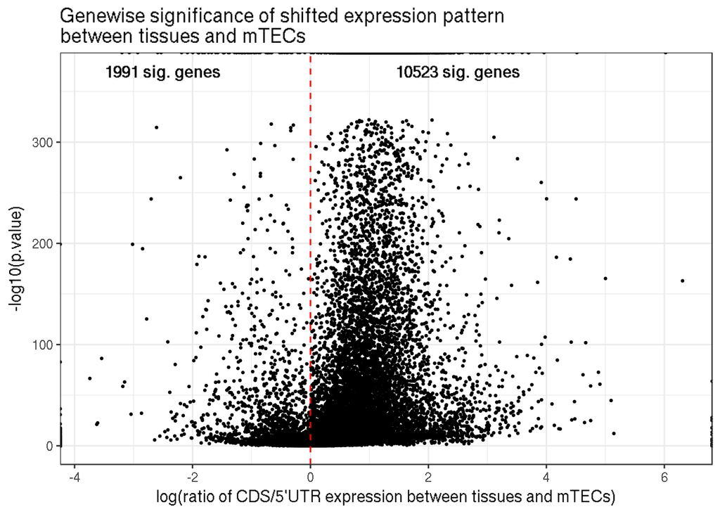

```r
#pdf(file="/home/stroemic/hiwi_16/analysis/shifted_TSS/plots/all_genes_p.value_vs_ratio.pdf")
gene_ids = c("MUC6","MLANA","INS")
ggplot(df, aes(x=log(ratio), y=-log10(p.value))) +
        geom_point(size=0.5) +
        geom_point(data=df[df$external_gene_name %in% gene_ids,], colour="blue", size=4) +
        geom_vline(xintercept = 0, linetype=2, colour= "red") +
        labs(title="Genewise significance of shifted expression pattern \nbetween tissues and mTECs", x ="log(ratio of CDS/5'UTR expression between tissues and mTECs)", y ="-log10(p.value)") +
        annotate("text", x=2.5, y=370, label=paste(nrow(df[df$p.value < 0.05 & df$ratio > 1, ])," sig. genes",sep=""), fontface =2) +
        annotate("text", x=-2.5, y=370, label =paste(nrow(df[df$p.value < 0.05 & df$ratio < 1, ])," sig. genes",sep=""), fontface =2) +
        theme_bw()
```

```r
#dev.off()
```